# RNA-Seq Report of Sample QC and Alignment Summary Statistics for SRP033351

Mengyuan Kan (mengykan@upenn.edu)

11 January, 2019

**Project:** SRP033351

**Aligner:** STAR (2.5.2b)

**Genome:** For human, the hg38 assembly was used. We estimate the number of rRNA reads as those mapped to chrM plus chrUn_GL000220v1, corresponding to 12S, 16S and 5.8S rRNA. The ‘Other’ category contains all other chr*random and chrUn* available.

**Informatics tools used:**

- Trimmomatic (0.32)
- FastQC (0.11.7)
- STAR (2.5.2b)
- samtools (1.8)
- bamtools (2.3.0)
- Picard Tools (1.96)

**Sequencing parameters:**

- library_type = PE
- strand = nonstrand

For each sample, the following programs were run to generate the data necessary to create this report. Written as for unstranded paired-end data. For single-end reads, R2s and insert size metrics would be omitted.

> java -Xmx1024m TrimmomaticPE -phred33 [raw_sample_R1] [raw_sample_R2] [sample_R1] [sample_R1_unpaired] [sample_R2] [sample_R2_unpaired] HEADCROP:[bases to trim, if any] ILLUMINACLIP:[sample_primer_fasta]:2:30:10 MINLEN:50  
> fastqc [sample_R1] [sample_R2]  
> cat [sample_R1/R2] | awk ’((NR-2)%4==0){read=$1;total++;count[read]++}END{for(read in count){if(count[read]==1){unique++}};print total,unique,unique*100/total}’

The following STAR options were used:

> STAR –genomeDir [ref_genome_index] –runThreadN 12 –outReadsUnmapped Fastx –outMultimapperOrder Random –outSAMmultNmax 1 –outFilterIntronMotifs RemoveNoncanonical –outSAMstrandField intronMotif –outSAMtype BAM SortedByCoordinate –readFilesIn [sample_R1] [sample_R2]

Using aligned output files accepted_hits.bam and unmapped.bam:

> samtools sort accepted_hits.bam accepted_hits.sorted  
> samtools index accepted_hits.sorted.bam  
> samtools idxstats accepted_hits.sorted.bam > accepted_hits.sorted.stats  
> bamtools stats -in accepted_hits.sorted.bam > accepted_hits.sorted.bamstats  
> bamtools filter -in accepted_hits.sorted.bam -script cigarN.script | bamtools count  
> samtools view -c unmapped.bam  
> java -Xmx2g -jar CollectRnaSeqMetrics.jar REF_FLAT=[ref_flat file] STRAND_SPECIFICITY=NONE INPUT=accepted_hits.bam OUTPUT=RNASeqMetrics  
> java -Xmx2g -jar CollectInsertSizeMetrics.jar HISTOGRAM_FILE=InsertSizeHist.pdf INPUT=accepted_hits.sorted.bam OUTPUT=InsertSizeMetrics (for paired-end library)

## Summary Read Numbers

The number of raw reads correspond to those that passed Casava QC filters, were trimmed to remove adaptors by Trimmomatic, and were aligned by STAR to ref_genome+ERCC transcripts as reported in .info files. Unique read counts were obtained by using awk on trimmed fastq files. FastQC estimates of percentage of sequences remaining after deduplication were retrieved from fastqc_data.txt files. Bamtools statistics were based on sorted and indexed bam files. The mapped reads were those that mapped to reference and were output by STAR to accepted_hits.bam. The unmapped reads were output by STAR to unmapped.bam. Some reads may be mapped to multiple locations in the genome so that the number of total reads reported by bamstats may be greater than the number of raw reads. The Junction spanning reads are computed based on accepted_hits.bam CIGAR entries containing “N.” Related text files that were saved:

SRP033351 _read_counts.txt

SRP033351 _duplicates.txt

SRP033351 _unique_counts.txt

SRP033351 _bamstats_counts.txt

### Total Number of Raw Reads Summary

Read counts are shown by per million reads.

| Sample | R1_Raw_Reads | R1_Unique_Reads | R1_Percent_Unique | R2_Raw_Reads | R2_Unique_Reads | R2_Percent_Unique | Fastqc_Total_Deduplicated_Percentage_R1 | Fastqc_Total_Deduplicated_Percentage_R2 |
| --- | --- | --- | --- | --- | --- | --- | --- | --- |
| SRR1039508 | 22.76 | 9.35 | 41.09 | 22.76 | 10.58 | 46.48 | 50.74 | 52.95 |
| SRR1039509 | 20.81 | 8.69 | 41.75 | 20.81 | 9.94 | 47.76 | 51.88 | 54.51 |
| SRR1039510 | 22.58 | 9.43 | 41.78 | 22.58 | 10.74 | 47.59 | 51.33 | 53.89 |
| SRR1039511 | 21.91 | 9.09 | 41.48 | 21.91 | 10.29 | 46.96 | 51.39 | 53.5 |
| SRR1039512 | 28.11 | 9.99 | 35.53 | 28.11 | 9.76 | 34.73 | 44.71 | 45.51 |
| SRR1039513 | 16.81 | 7.06 | 41.98 | 16.81 | 7.17 | 42.65 | 52.65 | 53.67 |
| SRR1039514 | 39.91 | 14.14 | 35.42 | 39.91 | 13.92 | 34.87 | 44.13 | 45.28 |
| SRR1039515 | 24.09 | 9.64 | 40 | 24.09 | 9.46 | 39.26 | 49.65 | 50.29 |
| SRR1039516 | 27.22 | 10.57 | 38.82 | 27.22 | 10.59 | 38.91 | 46.36 | 47.46 |
| SRR1039517 | 34.28 | 12.89 | 37.61 | 34.28 | 12.64 | 36.88 | 44.57 | 45.6 |

[output cut: 6 more lines]

### Plot: Percentage of Unique Reads in Original Fastq File

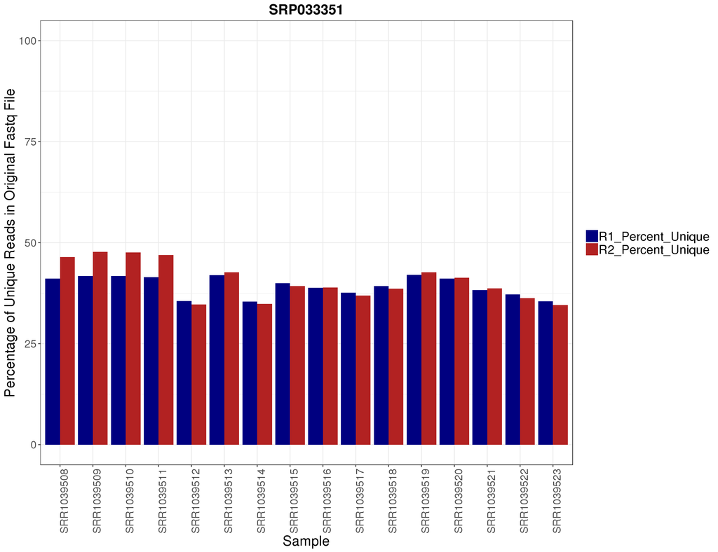

### Plot: Sequence Duplication Level

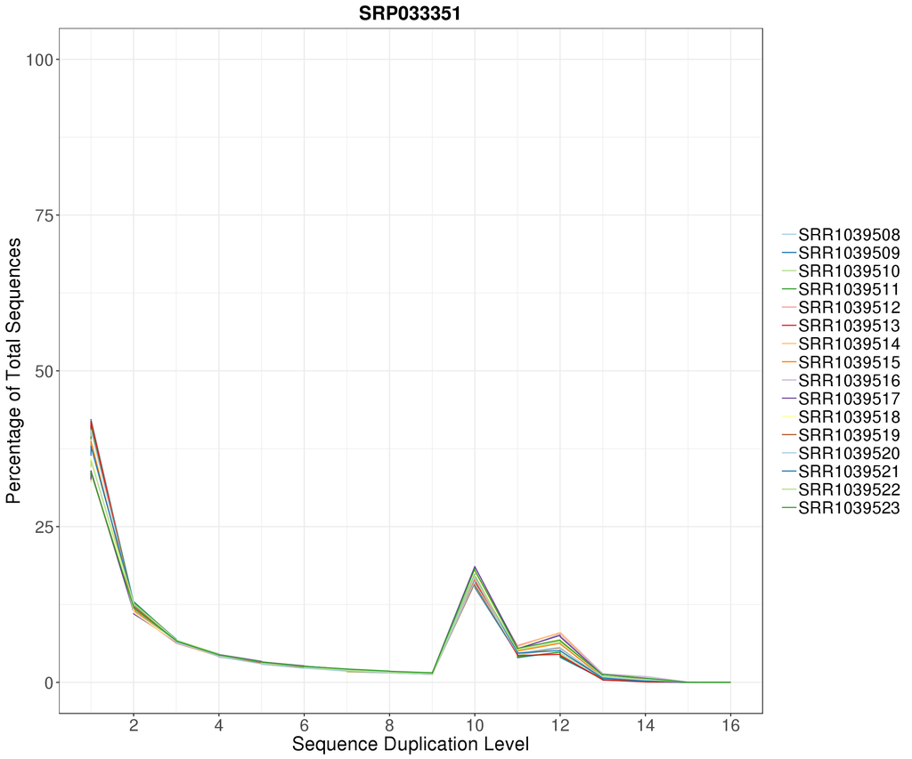

### Bamtools Reads Summary

|  | SRR1039508 | SRR1039509 | SRR1039510 | SRR1039511 | SRR1039512 | SRR1039513 | SRR1039514 | SRR1039515 | SRR1039516 | SRR1039517 | SRR1039518 | SRR1039519 | SRR1039520 | SRR1039521 | SRR1039522 | SRR1039523 |
| --- | --- | --- | --- | --- | --- | --- | --- | --- | --- | --- | --- | --- | --- | --- | --- | --- |
| Total reads | 45526278 | 41625102 | 45152844 | 43818090 | 56226486 | 33611674 | 79822270 | 48188522 | 54436880 | 68559802 | 60836692 | 44179490 | 42527950 | 46940310 | 56224014 | 62169134 |
| Mapped reads | 44723420 | 40768740 | 44297150 | 42962048 | 55246332 | 32919940 | 77931870 | 47251680 | 53424904 | 67369788 | 59696472 | 43325780 | 41674838 | 45913632 | 54983038 | 61048192 |
| Forward strand | 22361710 | 20384370 | 22148575 | 21481024 | 27623166 | 16459970 | 38965935 | 23625840 | 26712452 | 33684894 | 29848236 | 21662890 | 20837419 | 22956816 | 27491519 | 30524096 |
| Reverse strand | 22361710 | 20384370 | 22148575 | 21481024 | 27623166 | 16459970 | 38965935 | 23625840 | 26712452 | 33684894 | 29848236 | 21662890 | 20837419 | 22956816 | 27491519 | 30524096 |
| Paired-end reads | 44723420 | 40768740 | 44297150 | 42962048 | 55246332 | 32919940 | 77931870 | 47251680 | 53424904 | 67369788 | 59696472 | 43325780 | 41674838 | 45913632 | 54983038 | 61048192 |
| Proper-pairs | 44723420 | 40768740 | 44297150 | 42962048 | 55246332 | 32919940 | 77931870 | 47251680 | 53424904 | 67369788 | 59696472 | 43325780 | 41674838 | 45913632 | 54983038 | 61048192 |
| Both pairs mapped | 44723420 | 40768740 | 44297150 | 42962048 | 55246332 | 32919940 | 77931870 | 47251680 | 53424904 | 67369788 | 59696472 | 43325780 | 41674838 | 45913632 | 54983038 | 61048192 |
| Read 1 | 22361710 | 20384370 | 22148575 | 21481024 | 27623166 | 16459970 | 38965935 | 23625840 | 26712452 | 33684894 | 29848236 | 21662890 | 20837419 | 22956816 | 27491519 | 30524096 |
| Read 2 | 22361710 | 20384370 | 22148575 | 21481024 | 27623166 | 16459970 | 38965935 | 23625840 | 26712452 | 33684894 | 29848236 | 21662890 | 20837419 | 22956816 | 27491519 | 30524096 |
| Singletons | 0 | 0 | 0 | 0 | 0 | 0 | 0 | 0 | 0 | 0 | 0 | 0 | 0 | 0 | 0 | 0 |

[output cut: 2 more lines]

|  | SRR1039508 | SRR1039509 | SRR1039510 | SRR1039511 | SRR1039512 | SRR1039513 | SRR1039514 | SRR1039515 | SRR1039516 | SRR1039517 | SRR1039518 | SRR1039519 | SRR1039520 | SRR1039521 | SRR1039522 | SRR1039523 |
| --- | --- | --- | --- | --- | --- | --- | --- | --- | --- | --- | --- | --- | --- | --- | --- | --- |
| Total reads | 100 | 100 | 100 | 100 | 100 | 100 | 100 | 100 | 100 | 100 | 100 | 100 | 100 | 100 | 100 | 100 |
| Mapped reads | 98.24 | 97.94 | 98.1 | 98.05 | 98.26 | 97.94 | 97.63 | 98.06 | 98.14 | 98.26 | 98.13 | 98.07 | 97.99 | 97.81 | 97.79 | 98.2 |
| Forward strand | 49.12 | 48.97 | 49.05 | 49.02 | 49.13 | 48.97 | 48.82 | 49.03 | 49.07 | 49.13 | 49.06 | 49.03 | 49 | 48.91 | 48.9 | 49.1 |
| Reverse strand | 49.12 | 48.97 | 49.05 | 49.02 | 49.13 | 48.97 | 48.82 | 49.03 | 49.07 | 49.13 | 49.06 | 49.03 | 49 | 48.91 | 48.9 | 49.1 |
| Paired-end reads | 98.24 | 97.94 | 98.1 | 98.05 | 98.26 | 97.94 | 97.63 | 98.06 | 98.14 | 98.26 | 98.13 | 98.07 | 97.99 | 97.81 | 97.79 | 98.2 |
| Proper-pairs | 98.24 | 97.94 | 98.1 | 98.05 | 98.26 | 97.94 | 97.63 | 98.06 | 98.14 | 98.26 | 98.13 | 98.07 | 97.99 | 97.81 | 97.79 | 98.2 |
| Both pairs mapped | 98.24 | 97.94 | 98.1 | 98.05 | 98.26 | 97.94 | 97.63 | 98.06 | 98.14 | 98.26 | 98.13 | 98.07 | 97.99 | 97.81 | 97.79 | 98.2 |
| Read 1 | 49.12 | 48.97 | 49.05 | 49.02 | 49.13 | 48.97 | 48.82 | 49.03 | 49.07 | 49.13 | 49.06 | 49.03 | 49 | 48.91 | 48.9 | 49.1 |
| Read 2 | 49.12 | 48.97 | 49.05 | 49.02 | 49.13 | 48.97 | 48.82 | 49.03 | 49.07 | 49.13 | 49.06 | 49.03 | 49 | 48.91 | 48.9 | 49.1 |
| Singletons | 0 | 0 | 0 | 0 | 0 | 0 | 0 | 0 | 0 | 0 | 0 | 0 | 0 | 0 | 0 | 0 |

[output cut: 2 more lines]

### Percentage of Mapped/Unmapped Reads

|  | SRR1039508 | SRR1039509 | SRR1039510 | SRR1039511 | SRR1039512 | SRR1039513 | SRR1039514 | SRR1039515 | SRR1039516 | SRR1039517 | SRR1039518 | SRR1039519 | SRR1039520 | SRR1039521 | SRR1039522 | SRR1039523 |
| --- | --- | --- | --- | --- | --- | --- | --- | --- | --- | --- | --- | --- | --- | --- | --- | --- |
| Mapped reads | 98.24 | 97.94 | 98.1 | 98.05 | 98.26 | 97.94 | 97.63 | 98.06 | 98.14 | 98.26 | 98.13 | 98.07 | 97.99 | 97.81 | 97.79 | 98.2 |
| Unmapped reads | 1.76 | 2.06 | 1.9 | 1.95 | 1.74 | 2.06 | 2.37 | 1.94 | 1.86 | 1.74 | 1.87 | 1.93 | 2.01 | 2.19 | 2.21 | 1.8 |

### Plot: Percentage of Mapped/Unmapped Reads

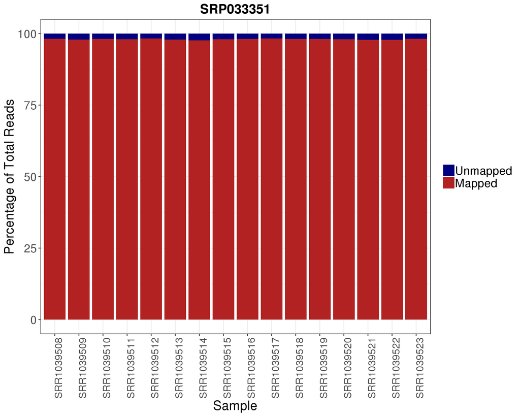

### Plot: Percentage of Junction Spanning Reads Among Mapped Reads

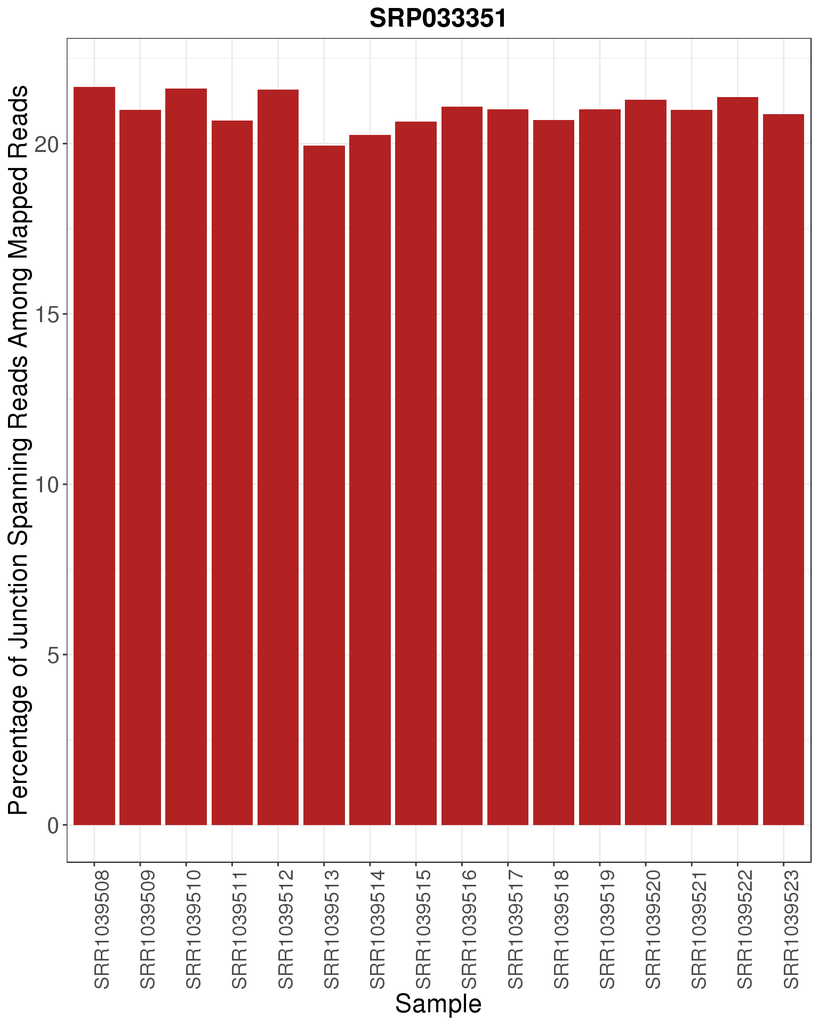

## RnaSeqMetrics Summary

The Picard Tools RnaSeqMetrics function computes the number of bases assigned to various classes of RNA. It also computes the coverage of bases across all transcripts (normalized to a same-sized reference). Computations are based on comparison to a refFlat file. Related text files that were saved:

SRP033351 _rnaseqmetrics_summary.txt

SRP033351 _rnaseqmetrics_hist.txt

### Reference Genome Mapped Reads Summary

|  | SRR1039508 | SRR1039509 | SRR1039510 | SRR1039511 | SRR1039512 | SRR1039513 | SRR1039514 | SRR1039515 | SRR1039516 | SRR1039517 | SRR1039518 | SRR1039519 | SRR1039520 | SRR1039521 | SRR1039522 | SRR1039523 |
| --- | --- | --- | --- | --- | --- | --- | --- | --- | --- | --- | --- | --- | --- | --- | --- | --- |
| PF_BASES | 2817572128 | 2568428034 | 2790717997 | 2706607712 | 3480518101 | 2073955487 | 4909705941 | 2976854504 | 3365768248 | 4244295604 | 3760876330 | 2729523206 | 2625513961 | 2892557906 | 3463930333 | 3846034523 |
| PF_ALIGNED_BASES | 2807794720 | 2558846454 | 2780831924 | 2696883163 | 3469492589 | 2065991704 | 4890759665 | 2965949642 | 3354679840 | 4229164255 | 3746886017 | 2719507029 | 2615173581 | 2880931777 | 3451305113 | 3831777044 |
| CODING_BASES | 1715170400 | 1535903197 | 1690138623 | 1606557058 | 2131873628 | 1191591741 | 2898190007 | 1755220641 | 2039593348 | 2565687730 | 2231954219 | 1613862872 | 1587478209 | 1749092653 | 2080563501 | 2313458537 |
| UTR_BASES | 920252536 | 873018021 | 908721638 | 920768230 | 1127902562 | 763166164 | 1709181476 | 1021060884 | 1102416958 | 1409324961 | 1289004122 | 934463888 | 865200268 | 968851111 | 1147752283 | 1276433358 |
| INTRONIC_BASES | 127265861 | 112947545 | 137535039 | 128643391 | 158167752 | 81047333 | 212661322 | 144401074 | 161089882 | 193894801 | 168147008 | 127989090 | 122616160 | 118627915 | 168425280 | 182461232 |
| INTERGENIC_BASES | 45105923 | 36977691 | 44436624 | 40914484 | 51548647 | 30186466 | 70726860 | 45267043 | 51579652 | 60256763 | 57780668 | 43191179 | 39878944 | 44360098 | 54564049 | 59423917 |
| IGNORED_READS | 0 | 0 | 0 | 0 | 0 | 0 | 0 | 0 | 0 | 0 | 0 | 0 | 0 | 0 | 0 | 0 |
| CORRECT_STRAND_READS | 0 | 0 | 0 | 0 | 0 | 0 | 0 | 0 | 0 | 0 | 0 | 0 | 0 | 0 | 0 | 0 |
| INCORRECT_STRAND_READS | 0 | 0 | 0 | 0 | 0 | 0 | 0 | 0 | 0 | 0 | 0 | 0 | 0 | 0 | 0 | 0 |
| PCT_CODING_BASES | 61.09 | 60.02 | 60.78 | 59.57 | 61.45 | 57.68 | 59.26 | 59.18 | 60.8 | 60.67 | 59.57 | 59.34 | 60.7 | 60.71 | 60.28 | 60.38 |

[output cut: 10 more lines]

### Plot: Percentages of Total Mapped Bases Mapping to mRNA, Intronic and Intergenic Regions

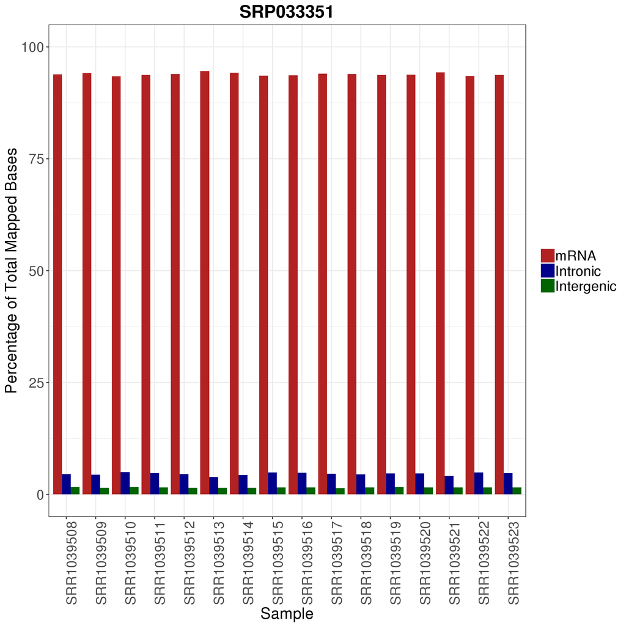

### Plot: Normalized Coverage

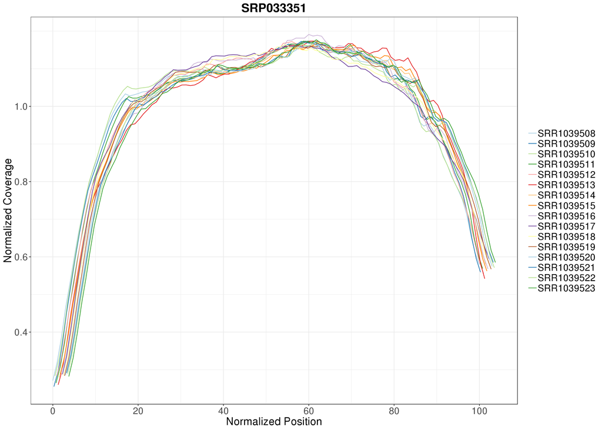

## InsertSizeMetrics Summary

For paired-end data, the Picard Tools CollectInsertSizeMetrics function was used to compute the distribution of insert sizes in the accepted_hits.bam file and create a histogram. Related text files that were saved:

SRP033351 _insertmetrics_summary.txt

|  | SRR1039508 | SRR1039509 | SRR1039510 | SRR1039511 | SRR1039512 | SRR1039513 | SRR1039514 | SRR1039515 | SRR1039516 | SRR1039517 | SRR1039518 | SRR1039519 | SRR1039520 | SRR1039521 | SRR1039522 | SRR1039523 |
| --- | --- | --- | --- | --- | --- | --- | --- | --- | --- | --- | --- | --- | --- | --- | --- | --- |
| MEDIAN_INSERT_SIZE | 203 | 206 | 245 | 206 | 219 | 195 | 193 | 195 | 223 | 206 | 201 | 202 | 203 | 203 | 224 | 199 |
| MEDIAN_ABSOLUTE_DEVIATION | 102 | 103 | 137 | 101 | 114 | 90 | 90 | 91 | 114 | 102 | 97 | 100 | 99 | 99 | 116 | 93 |
| MIN_INSERT_SIZE | 23 | 29 | 21 | 26 | 24 | 27 | 22 | 25 | 26 | 21 | 26 | 26 | 22 | 23 | 21 | 24 |
| MAX_INSERT_SIZE | 1704107 | 1552807 | 2451161 | 1808813 | 1137810 | 1369848 | 1552816 | 1552631 | 1845454 | 1554099 | 1645622 | 1552807 | 1704513 | 1552801 | 1452230 | 2198661 |
| MEAN_INSERT_SIZE | 259.795732 | 260.474806 | 334.951259 | 256.755205 | 286.326803 | 234.881102 | 233.184609 | 237.394857 | 288.310746 | 258.188085 | 248.276652 | 252.155832 | 254.435849 | 251.908875 | 293.154446 | 242.454612 |
| STANDARD_DEVIATION | 248.471446 | 248.203962 | 347.70994 | 240.559242 | 284.026695 | 209.093679 | 210.358058 | 214.749963 | 281.477608 | 245.774268 | 230.405848 | 238.867845 | 239.727206 | 237.376974 | 290.538488 | 220.648804 |
| READ_PAIRS | 22361710 | 20384370 | 22148575 | 21481024 | 27623166 | 16459970 | 38965935 | 23625840 | 26712452 | 33684894 | 29848236 | 21662890 | 20837419 | 22956816 | 27491519 | 30524096 |

### Plot: Median of Insert Size

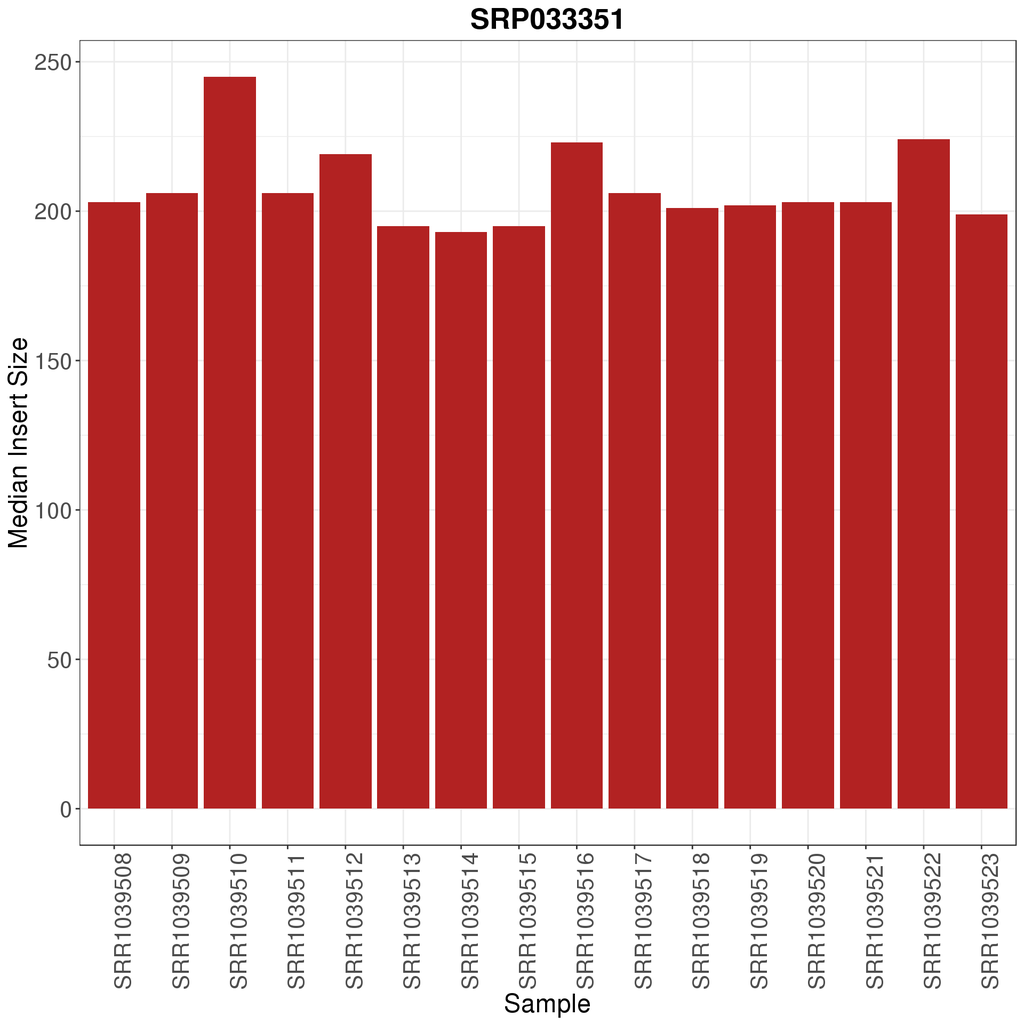

### Plot: Insert Size Distribution

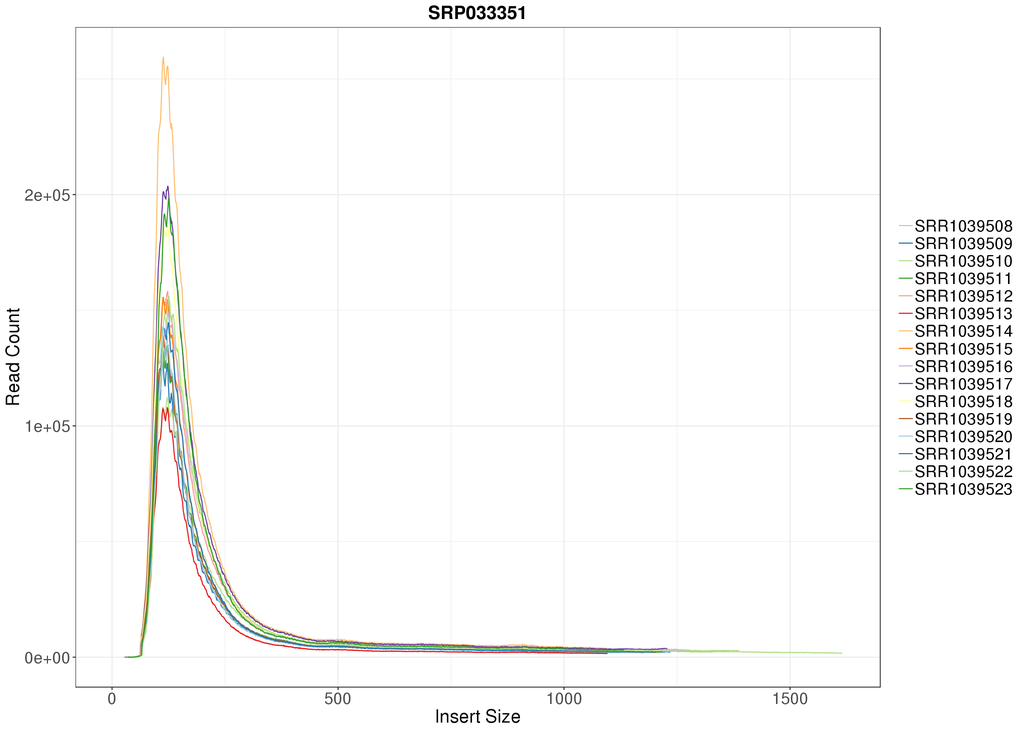

## Reads per Chromosome

Samtools produces a summary document that includes the number of reads mapped to each chromosome. Related text files that were saved:

SRP033351 _counts.txt

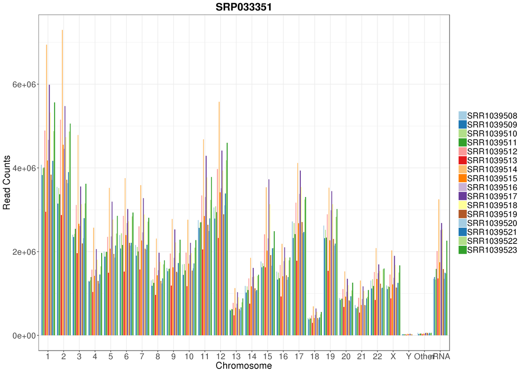

### Mapped Reads to Reference Genome

|  | SRR1039508 | SRR1039509 | SRR1039510 | SRR1039511 | SRR1039512 | SRR1039513 | SRR1039514 | SRR1039515 | SRR1039516 | SRR1039517 | SRR1039518 | SRR1039519 | SRR1039520 | SRR1039521 | SRR1039522 | SRR1039523 |
| --- | --- | --- | --- | --- | --- | --- | --- | --- | --- | --- | --- | --- | --- | --- | --- | --- |
| 1 | 4077658 | 3830338 | 3991506 | 4009662 | 4891936 | 2951722 | 6942390 | 4176800 | 4671162 | 5986590 | 5324690 | 3841054 | 3714588 | 4166970 | 4878364 | 5566322 |
| 2 | 3547632 | 3148220 | 3517544 | 3370864 | 5153056 | 2875772 | 7296296 | 4553232 | 4456792 | 5478008 | 4735196 | 3717640 | 3635840 | 3900394 | 4867696 | 5058528 |
| 3 | 2403406 | 2351170 | 2422128 | 2545122 | 3115448 | 1965464 | 4786252 | 2665228 | 2611554 | 3557058 | 3131926 | 2197864 | 2322894 | 2798136 | 3150756 | 3618728 |
| 4 | 1299370 | 1286162 | 1313602 | 1391818 | 1568368 | 1036958 | 2570458 | 1420636 | 1568598 | 2059740 | 1808632 | 1302492 | 1235278 | 1453804 | 1650578 | 1969708 |
| 5 | 2003830 | 1879138 | 1993858 | 1996284 | 2353176 | 1496962 | 3522612 | 2072034 | 2361354 | 3194802 | 2767470 | 1944214 | 1856884 | 2146622 | 2434972 | 2853456 |
| 6 | 2396452 | 2074056 | 2438594 | 2158430 | 2854490 | 1524980 | 3755020 | 2394444 | 2683110 | 3017686 | 2724610 | 2211654 | 2144048 | 2209202 | 2841464 | 2933240 |
| 7 | 2159228 | 1904576 | 2113576 | 2007770 | 2603578 | 1574780 | 3588448 | 2263470 | 2458840 | 3276044 | 2887480 | 2068854 | 2046634 | 2161464 | 2714074 | 2807672 |
| 8 | 1315346 | 1186644 | 1336506 | 1256088 | 1616676 | 968010 | 2311708 | 1435536 | 1554110 | 1972866 | 1754956 | 1302718 | 1241528 | 1361346 | 1692886 | 1792324 |
| 9 | 1610846 | 1533430 | 1587248 | 1591486 | 1956890 | 1188386 | 2779528 | 1626950 | 1851152 | 2529258 | 2217616 | 1518572 | 1494952 | 1725294 | 1970566 | 2286204 |
| 10 | 1693258 | 1444496 | 1702806 | 1550142 | 1977120 | 1177446 | 2763164 | 1713486 | 1915800 | 2209396 | 1965532 | 1547534 | 1600194 | 1719384 | 2094128 | 2274298 |

[output cut: 17 more lines]

### Percent of Total Reads Mapped to Reference Genome

|  | SRR1039508 | SRR1039509 | SRR1039510 | SRR1039511 | SRR1039512 | SRR1039513 | SRR1039514 | SRR1039515 | SRR1039516 | SRR1039517 | SRR1039518 | SRR1039519 | SRR1039520 | SRR1039521 | SRR1039522 | SRR1039523 |
| --- | --- | --- | --- | --- | --- | --- | --- | --- | --- | --- | --- | --- | --- | --- | --- | --- |
| 1 | 9.12 | 9.4 | 9.01 | 9.33 | 8.85 | 8.97 | 8.91 | 8.84 | 8.74 | 8.89 | 8.92 | 8.87 | 8.91 | 9.08 | 8.87 | 9.12 |
| 2 | 7.93 | 7.72 | 7.94 | 7.85 | 9.33 | 8.74 | 9.36 | 9.64 | 8.34 | 8.13 | 7.93 | 8.58 | 8.73 | 8.5 | 8.85 | 8.29 |
| 3 | 5.37 | 5.77 | 5.47 | 5.92 | 5.64 | 5.97 | 6.14 | 5.64 | 4.89 | 5.28 | 5.25 | 5.07 | 5.57 | 6.1 | 5.73 | 5.93 |
| 4 | 2.91 | 3.15 | 2.97 | 3.24 | 2.84 | 3.15 | 3.3 | 3.01 | 2.94 | 3.06 | 3.03 | 3.01 | 2.96 | 3.17 | 3 | 3.23 |
| 5 | 4.48 | 4.61 | 4.5 | 4.65 | 4.26 | 4.55 | 4.52 | 4.39 | 4.42 | 4.74 | 4.64 | 4.49 | 4.46 | 4.68 | 4.43 | 4.67 |
| 6 | 5.36 | 5.09 | 5.51 | 5.02 | 5.17 | 4.63 | 4.82 | 5.07 | 5.02 | 4.48 | 4.56 | 5.1 | 5.15 | 4.81 | 5.17 | 4.81 |
| 7 | 4.83 | 4.67 | 4.77 | 4.67 | 4.71 | 4.78 | 4.61 | 4.79 | 4.6 | 4.86 | 4.84 | 4.78 | 4.91 | 4.71 | 4.94 | 4.6 |
| 8 | 2.94 | 2.91 | 3.02 | 2.92 | 2.93 | 2.94 | 2.97 | 3.04 | 2.91 | 2.93 | 2.94 | 3.01 | 2.98 | 2.97 | 3.08 | 2.94 |
| 9 | 3.6 | 3.76 | 3.58 | 3.7 | 3.54 | 3.61 | 3.57 | 3.44 | 3.46 | 3.75 | 3.71 | 3.51 | 3.59 | 3.76 | 3.58 | 3.75 |
| 10 | 3.79 | 3.54 | 3.84 | 3.61 | 3.58 | 3.58 | 3.55 | 3.63 | 3.59 | 3.28 | 3.29 | 3.57 | 3.84 | 3.75 | 3.81 | 3.73 |

[output cut: 17 more lines]

## ERCC Spike-in Dose Response Plots

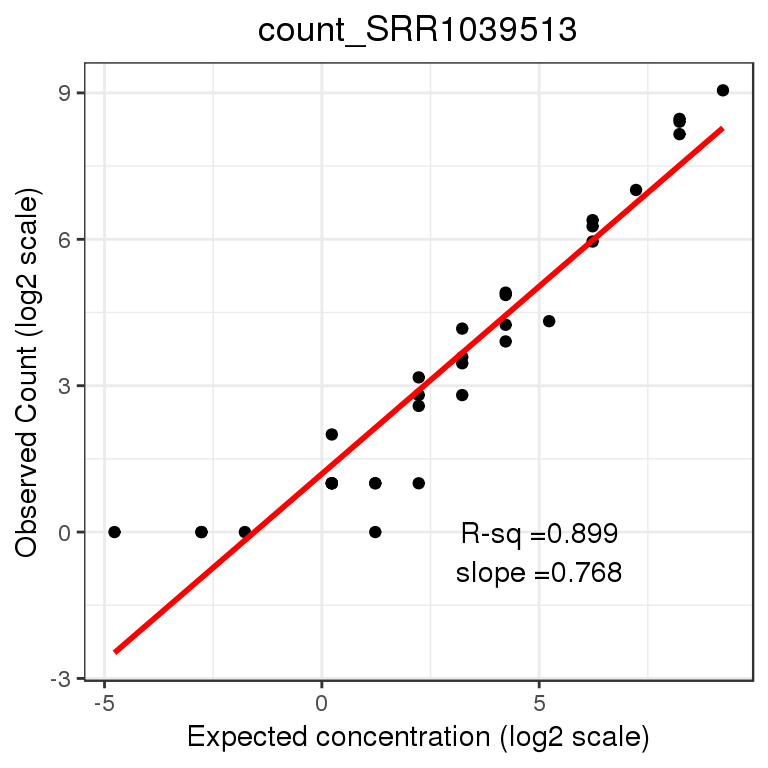

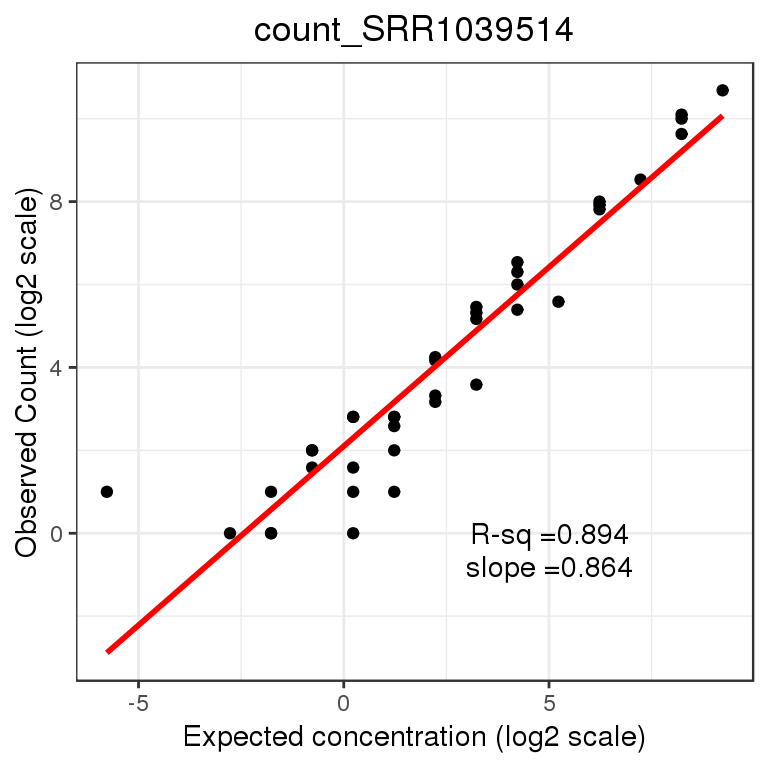

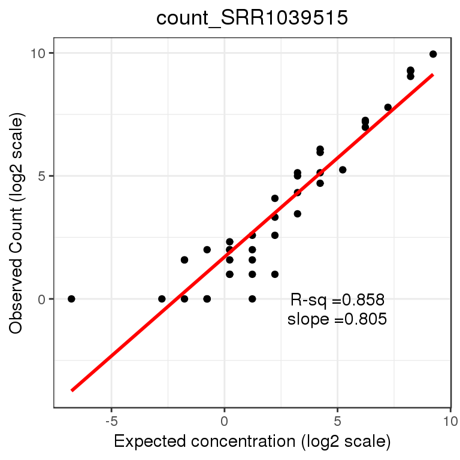

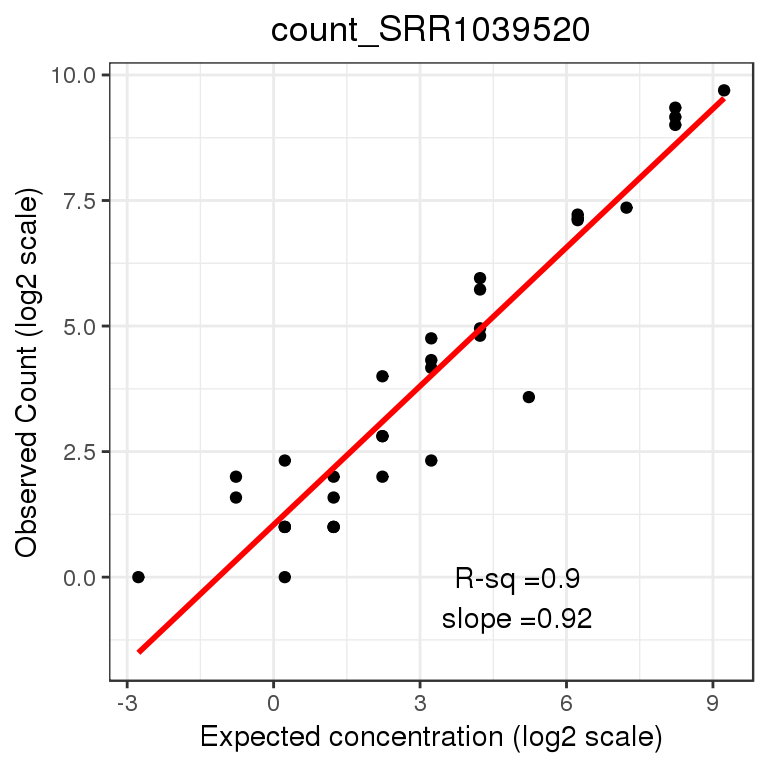

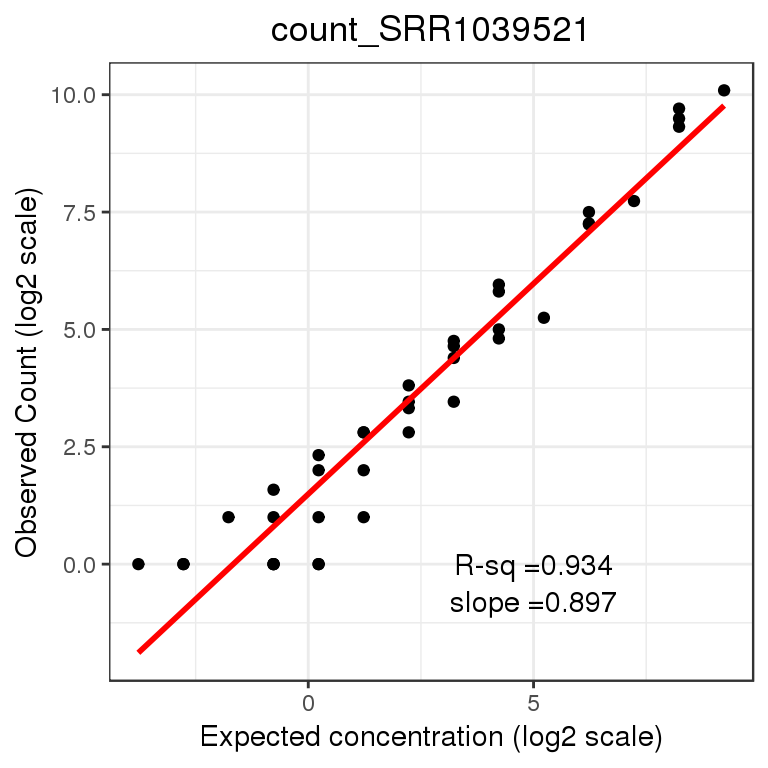

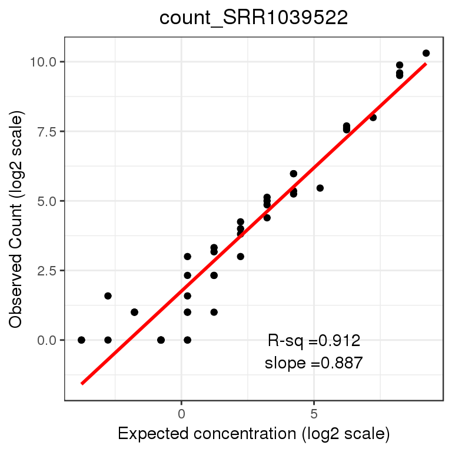

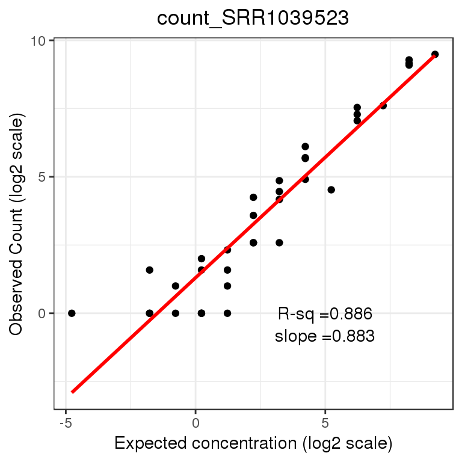

| Sample | r2 | slope |
| --- | --- | --- |
| SRR1039513 | 0.9 | 0.77 |
| SRR1039514 | 0.89 | 0.86 |
| SRR1039515 | 0.86 | 0.8 |
| SRR1039520 | 0.9 | 0.92 |
| SRR1039521 | 0.93 | 0.9 |
| SRR1039522 | 0.91 | 0.89 |
| SRR1039523 | 0.89 | 0.88 |

## Principal Component Analysis (PCA) Plot

1. Compute PCs and variance explained by the first 10 PCs

Variance explained

| PC | Proportion of Variance (%) | Cumulative Proportion of Variance (%) |
| --- | --- | --- |
| PC1 | 40.37 | 40.37 |
| PC2 | 28.32 | 68.68 |
| PC3 | 14.98 | 83.66 |
| PC4 | 10.19 | 93.85 |
| PC5 | 2.187 | 96.04 |
| PC6 | 1.182 | 97.22 |
| PC7 | 0.7978 | 98.02 |
| PC8 | 0.5397 | 98.56 |
| PC9 | 0.3911 | 98.95 |
| PC10 | 0.2602 | 99.21 |

2. PCA plots

PCA plots are generated using the first two principle components colored by known factors (e.g. treatment/disease conditions, tissue, and donors), visualizing similarities between arrays and these similarities’ correlation to batch effects.

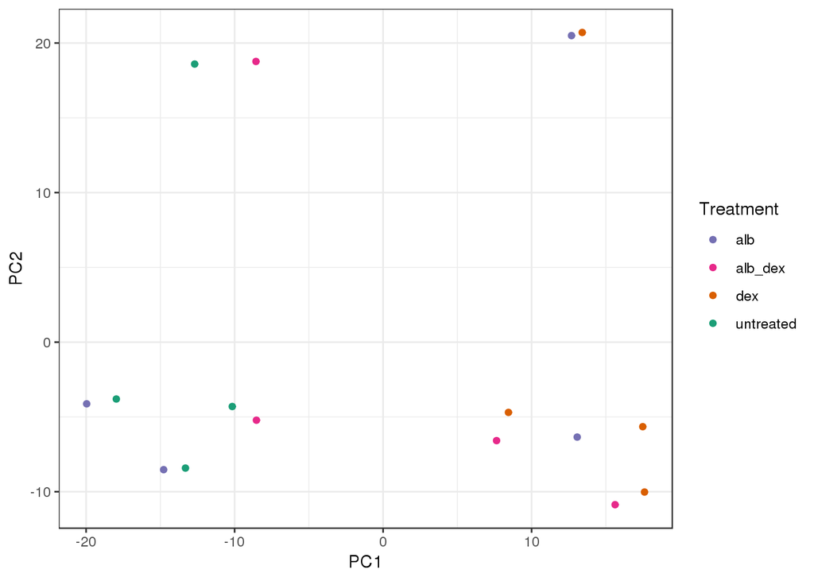

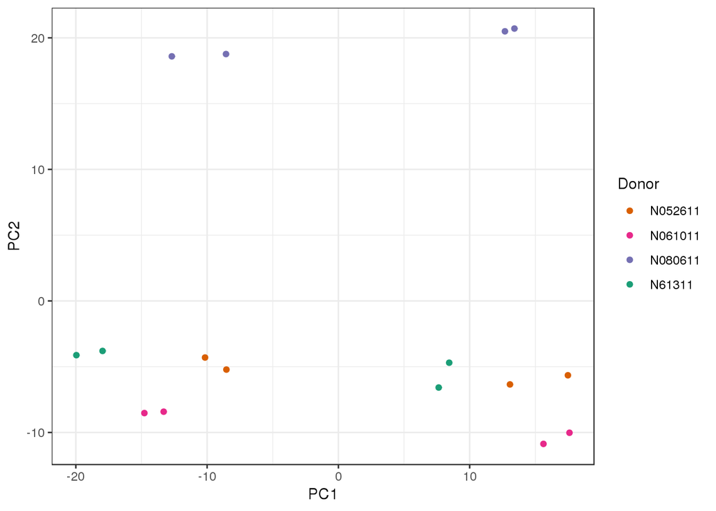

## HTSeq-count: No feature counts statistics

Numbers of reads that can not mapped to any feature (Nofeature count) are shown by per million reads from htseq-count quantification results

| Sample | Total_count | Nofeature_count | Nofeature_count_Percentage |
| --- | --- | --- | --- |
| SRR1039508 | 22.362 | 0.995 | 4.45 |
| SRR1039509 | 20.384 | 0.895 | 4.39 |
| SRR1039510 | 22.149 | 1.088 | 4.91 |
| SRR1039511 | 21.481 | 1.022 | 4.76 |
| SRR1039512 | 27.623 | 1.274 | 4.61 |
| SRR1039513 | 16.46 | 0.662 | 4.02 |
| SRR1039514 | 38.966 | 1.731 | 4.44 |
| SRR1039515 | 23.626 | 1.174 | 4.97 |
| SRR1039516 | 26.712 | 1.291 | 4.83 |
| SRR1039517 | 33.685 | 1.555 | 4.62 |

[output cut: 6 more lines]

**R version 3.4.3 (2017-11-30)**

**Platform:** x86_64-redhat-linux-gnu (64-bit)

**locale:** *LC_CTYPE=en_US.UTF-8*, *LC_NUMERIC=C*, *LC_TIME=en_US.UTF-8*, *LC_COLLATE=en_US.UTF-8*, *LC_MONETARY=en_US.UTF-8*, *LC_MESSAGES=en_US.UTF-8*, *LC_PAPER=en_US.UTF-8*, *LC_NAME=C*, *LC_ADDRESS=C*, *LC_TELEPHONE=C*, *LC_MEASUREMENT=en_US.UTF-8* and *LC_IDENTIFICATION=C*

**attached base packages:** *parallel*, *stats4*, *stats*, *graphics*, *grDevices*, *utils*, *datasets*, *methods* and *base*

**other attached packages:** *DESeq2(v.1.18.1)*, *SummarizedExperiment(v.1.8.1)*, *DelayedArray(v.0.4.1)*, *matrixStats(v.0.54.0)*, *Biobase(v.2.38.0)*, *GenomicRanges(v.1.30.3)*, *GenomeInfoDb(v.1.14.0)*, *IRanges(v.2.12.0)*, *S4Vectors(v.0.16.0)*, *BiocGenerics(v.0.24.0)*, *knitr(v.1.20)*, *ggplot2(v.3.0.0)*, *DT(v.0.4)*, *RColorBrewer(v.1.1-2)*, *pander(v.0.6.1)*, *tidyr(v.0.8.1)* and *rmarkdown(v.1.9)*

**loaded via a namespace (and not attached):** *bit64(v.0.9-7)*, *jsonlite(v.1.5)*, *splines(v.3.4.3)*, *Formula(v.1.2-2)*, *shiny(v.1.1.0)*, *assertthat(v.0.2.0)*, *latticeExtra(v.0.6-28)*, *blob(v.1.1.1)*, *GenomeInfoDbData(v.1.0.0)*, *yaml(v.2.1.18)*, *RSQLite(v.2.0)*, *pillar(v.1.2.1)*, *backports(v.1.1.2)*, *lattice(v.0.20-35)*, *glue(v.1.3.0)*, *digest(v.0.6.16)*, *promises(v.1.0.1)*, *XVector(v.0.18.0)*, *checkmate(v.1.8.5)*, *colorspace(v.1.3-2)*, *htmltools(v.0.3.6)*, *httpuv(v.1.4.3)*, *Matrix(v.1.2-12)*, *plyr(v.1.8.4)*, *XML(v.3.98-1.10)*, *pkgconfig(v.2.0.2)*, *genefilter(v.1.60.0)*, *zlibbioc(v.1.24.0)*, *purrr(v.0.2.5)*, *xtable(v.1.8-2)*, *scales(v.1.0.0)*, *later(v.0.7.3)*, *BiocParallel(v.1.12.0)*, *annotate(v.1.56.2)*, *tibble(v.1.4.2)*, *htmlTable(v.1.11.2)*, *withr(v.2.1.2)*, *nnet(v.7.3-12)*, *lazyeval(v.0.2.1)*, *survival(v.2.41-3)*, *magrittr(v.1.5)*, *mime(v.0.5)*, *memoise(v.1.1.0)*, *evaluate(v.0.10.1)*, *foreign(v.0.8-69)*, *data.table(v.1.11.4)*, *tools(v.3.4.3)*, *stringr(v.1.3.0)*, *locfit(v.1.5-9.1)*, *munsell(v.0.5.0)*, *cluster(v.2.0.6)*, *AnnotationDbi(v.1.40.0)*, *bindrcpp(v.0.2.2)*, *compiler(v.3.4.3)*, *rlang(v.0.2.2)*, *grid(v.3.4.3)*, *RCurl(v.1.95-4.10)*, *rstudioapi(v.0.7)*, *htmlwidgets(v.1.2)*, *crosstalk(v.1.0.0)*, *bitops(v.1.0-6)*, *base64enc(v.0.1-3)*, *labeling(v.0.3)*, *gtable(v.0.2.0)*, *DBI(v.0.8)*, *R6(v.2.2.2)*, *gridExtra(v.2.3)*, *dplyr(v.0.7.6)*, *bit(v.1.1-12)*, *bindr(v.0.1.1)*, *Hmisc(v.4.1-1)*, *rprojroot(v.1.3-2)*, *stringi(v.1.2.3)*, *Rcpp(v.0.12.18)*, *geneplotter(v.1.56.0)*, *rpart(v.4.1-11)*, *acepack(v.1.4.1)* and *tidyselect(v.0.2.4)*